# A3-Map Reduce on AWS

Aditya Kammardi Sathyanarayan

October 6, 2017

# Cluster Architecture -1

#### Namenode : 1

#### Datanode : 2

#### Ec2-Instance type - m4.2x.large

# Cluster Architecture -2

#### Namenode : 1

#### Datanode : 4

#### Ec2-Instance type - m4.2x.large

# Implmentation of Neighborhood score

> Like in the last assignment the neighborhood scoring is done in two map reduce phases , phase 1 involves counting the frequency of each letter in the corpus in one map reduce phase , phase 2 involves computing the neighborhood score using the result of phase 1. There is a small change in the reduce ,phase as compared to last time ,instead of computing the mean of the neighborhood scores of a word, the median is computed. I have implemented the bruteforce way of sorting the values that come to the reduce phase and picking the middle element in the sorted values.

# Experiment - K = 2 Cluster Architecture 2

Below we have the data measured by the Job History tracker , this was manually extracted. Also trials are against only one huge file ,

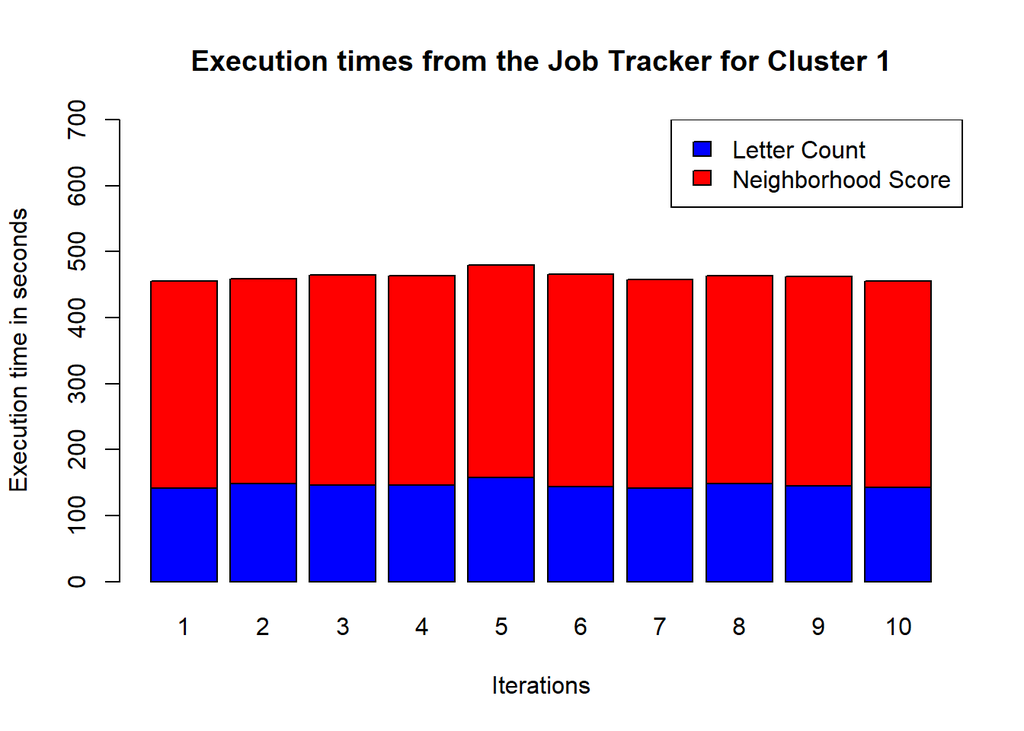

> The above graph is comparing the execution times in seconds on y - axis and the iterations on the x -axis. This data was extracted from the Job History server.It shows the time for Letter Count job and the time for Neighborhood Score job

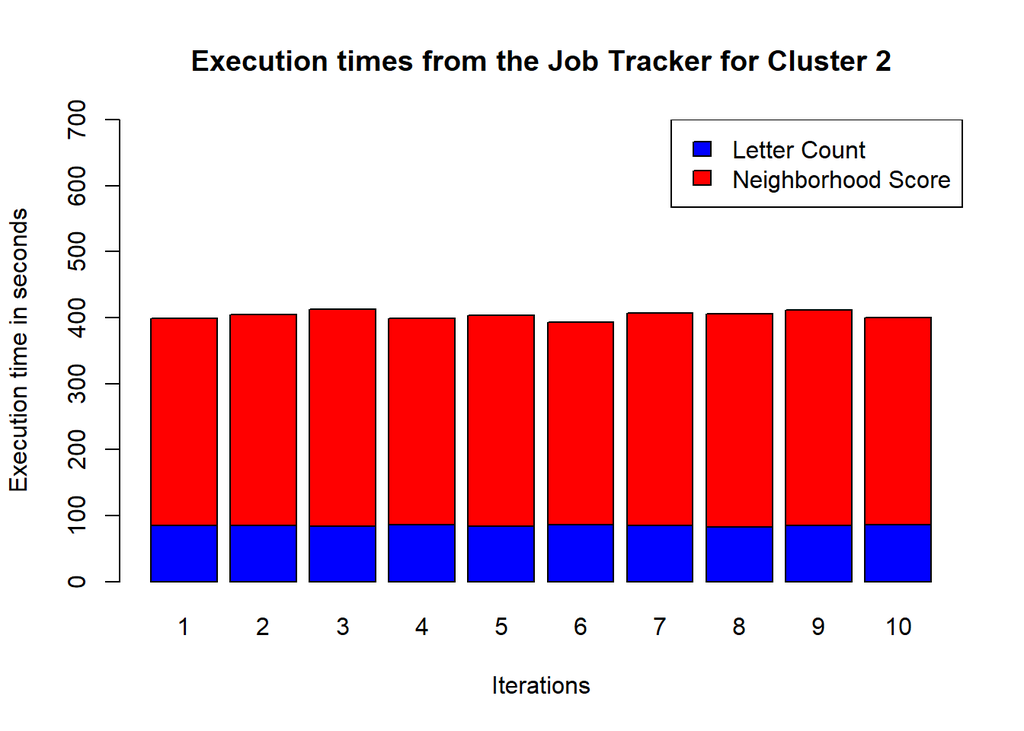

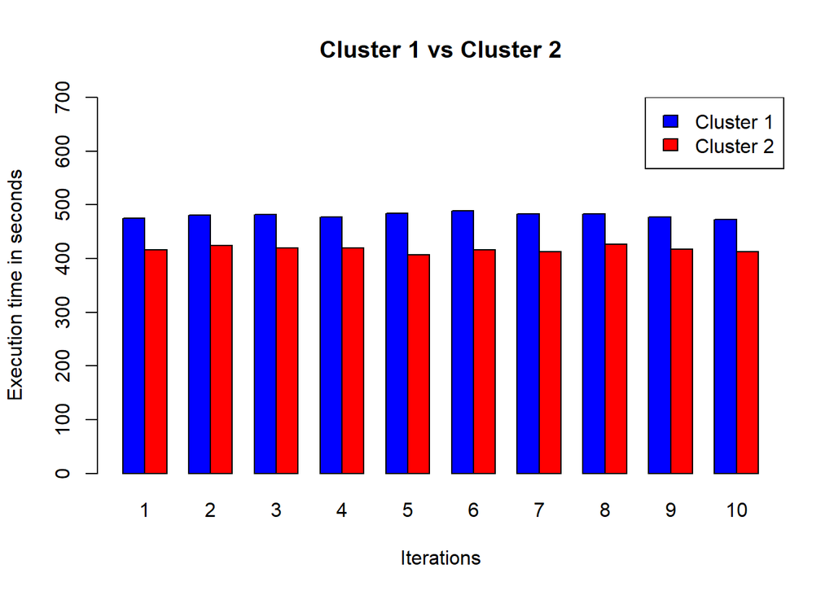